# ARIMA with Examples

CUNY DATA 624 Predictive Analytics: Instructor Jeff Nieman

Alexander Ng, Philip Tanofsky

10/12/2021

## GDP DATA EXAMPLE

### Create tsibble with YEAR column as index (quarterly data)

Plot data with autoplot

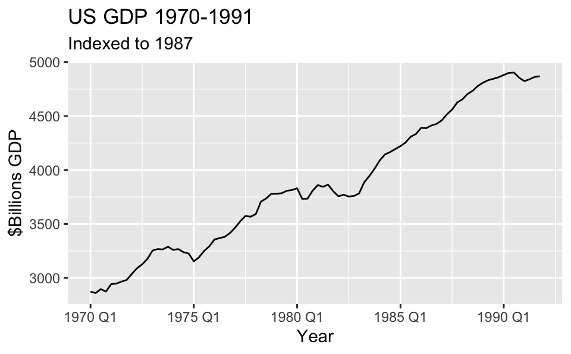

```r
rawdata = read_table("Table 21.1.txt",
                     skip = 9,
                     col_types = list( YEAR = col_character()))

rawdata %>% mutate( YEAR2 = str_replace(YEAR, "\\.", " Q")) -> aa

aa %>% dplyr::select(YEAR2, GDP , PDI, PCE, PROFITS, DIVIDENDS ) %>%
   mutate(YEAR= yearquarter(YEAR2)) %>%
   select(YEAR, GDP, PDI, PCE, PROFITS, DIVIDENDS) %>%
   as_tsibble(index=YEAR) -> econdata

econdata %>% autoplot(GDP) +
  labs(title="US GDP 1970-1991", subtitle="Indexed to 1987") +
  xlab("Year") + ylab("$Billions GDP")
```

## GDP DATA EXAMPLE 2

Take log of GDP, plot data with autoplot()

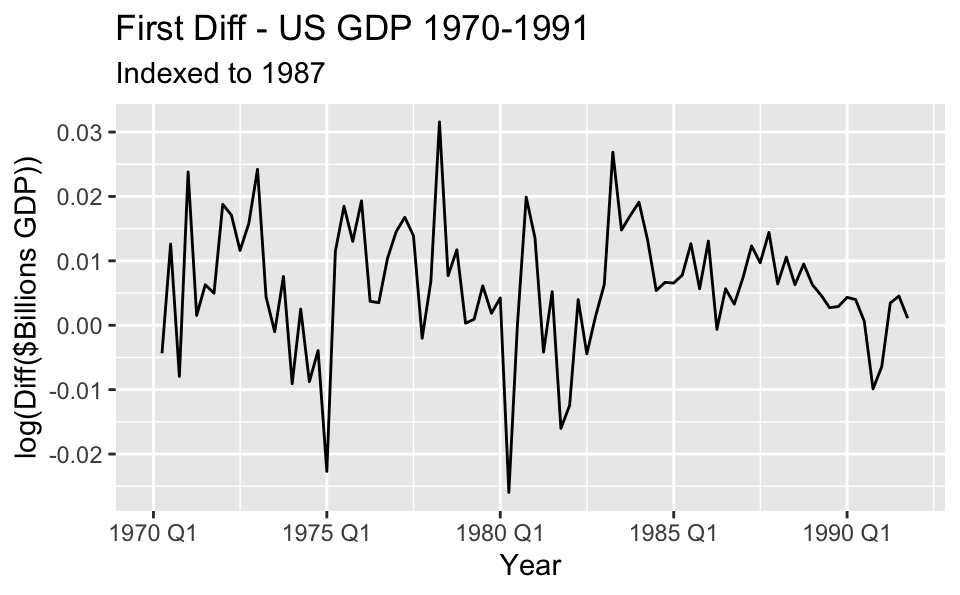

```r
econdata %>%  autoplot(difference(log(GDP), lag=1)) +
  labs(title=  "First Diff - US GDP 1970-1991", subtitle="Indexed to 1987") +
  xlab("Year") + ylab("log(Diff($Billions GDP))")
```

```r
econdata %>% dplyr::select(YEAR, GDP) %>% mutate( logGDP = log(GDP)) -> gdpdata

gdpdata
```

```
## # A tsibble: 88 x 3 [1Q]
##       YEAR   GDP logGDP
##      <qtr> <dbl>  <dbl>
##  1 1970 Q1 2873.   7.96
##  2 1970 Q2 2860.   7.96
##  3 1970 Q3 2897.   7.97
##  4 1970 Q4 2874.   7.96
##  5 1971 Q1 2943.   7.99
##  6 1971 Q2 2947.   7.99
##  7 1971 Q3 2966    7.99
##  8 1971 Q4 2981.   8.00
##  9 1972 Q1 3037.   8.02
## 10 1972 Q2 3090.   8.04
## # … with 78 more rows
```

### Generate model with fable ARIMA function

ARIMA(1,1,0) with drift

```r
fit <- gdpdata %>% model(ARIMA(logGDP))
```

## Checking ACF and PACF Plots

gg_tsdisplay() straight from the book

Check differences and ACF/PACF

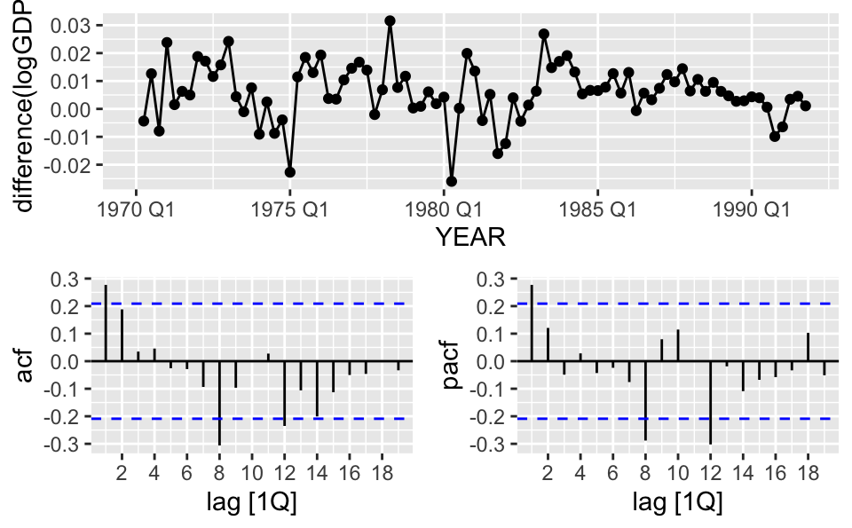

```r
gdpdata %>% gg_tsdisplay( difference(logGDP), plot_type='partial')
```

## Approach 1: Automated Model Selection

`fable` has automated model selection algorithm

Forecast ahead 5 intervals

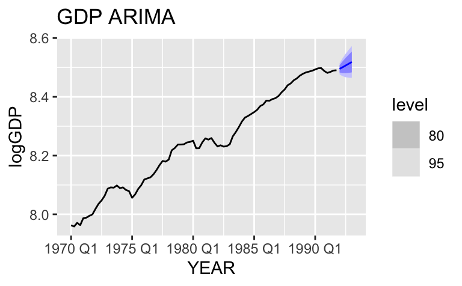

```r
fc = fit %>% forecast(h=5)

fc %>%  autoplot(gdpdata) +
  labs(title="GDP ARIMA")
```

```r
report(fit)
```

```
## Series: logGDP
## Model: ARIMA(1,1,0) w/ drift
##
## Coefficients:
##          ar1  constant
##       0.2783    0.0043
## s.e.  0.1031    0.0010
##
## sigma^2 estimated as 9.211e-05:  log likelihood=282.1
## AIC=-558.21   AICc=-557.92   BIC=-550.81
```

## Approach 1: Model Diagnostics - Bad News

The residuals of the ARIMA(1,1,0) model don’t look like white noise.

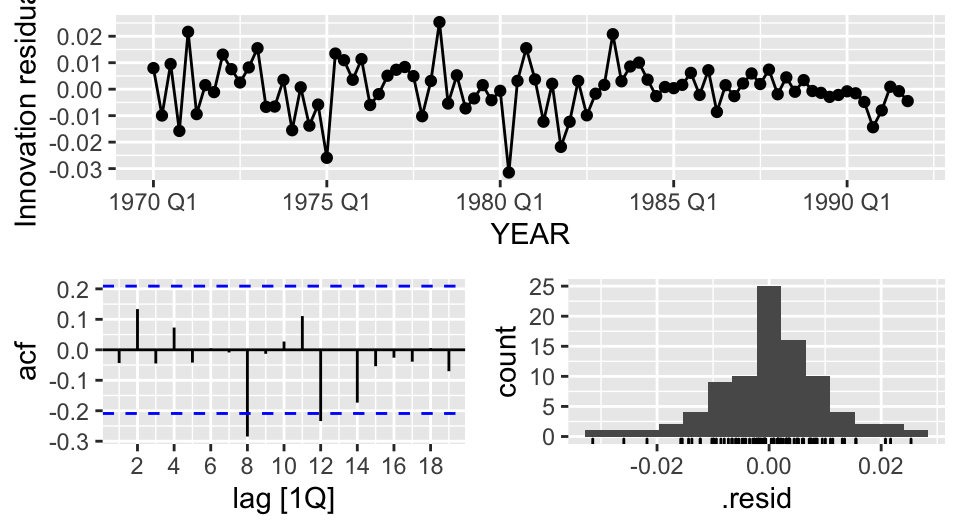

```r
fit %>% gg_tsresiduals()
```

## Approach 1: Model Diagnostics - Formal Test

```r
augment(fit) %>% features(.innov, ljung_box, lag=12, dof=2)
```

```
## # A tibble: 1 × 3
##   .model        lb_stat lb_pvalue
##   <chr>           <dbl>     <dbl>
## 1 ARIMA(logGDP)    17.8    0.0593
```

## Approach 2: Final ARIMA Model for GDP

For this example, use `arima` in `stats` library instead of `fable`.

## Approach 2: ARIMA Model Specification

```r
gdpdata$DGDP = difference(gdpdata$GDP,lag=1)

modDGDP = arima(gdpdata$DGDP[2:88], order = c(12, 0, 0), include.mean = TRUE ,
    fixed=c(NA, 0, 0, 0, 0, 0, 0, NA, 0, 0, 0, NA, NA) )
modDGDP
```

```
##
## Call:
## arima(x = gdpdata$DGDP[2:88], order = c(12, 0, 0), include.mean = TRUE, fixed = c(NA,
##     0, 0, 0, 0, 0, 0, NA, 0, 0, 0, NA, NA))
##
## Coefficients:
##          ar1  ar2  ar3  ar4  ar5  ar6  ar7      ar8  ar9  ar10  ar11     ar12
##       0.2982    0    0    0    0    0    0  -0.2873    0     0     0  -0.2626
## s.e.     NaN    0    0    0    0    0    0      NaN    0     0     0   0.0910
##       intercept
##         23.5659
## s.e.     2.7580
##
## sigma^2 estimated as 938.7:  log likelihood = -422.19,  aic = 854.38
```

We perform 2 unit root tests: KPSS and ADF. Both confirm stationarity in this case but sometimes they can disagree.

```r
kpss_val = tseries::kpss.test(gdpdata$DGDP[2:88], null=c("Level"), lshort = FALSE)

kpss_val
```

```
##
##  KPSS Test for Level Stationarity
##
## data:  gdpdata$DGDP[2:88]
## KPSS Level = 0.0626, Truncation lag parameter = 11, p-value = 0.1
```

```r
adf_val = tseries::adf.test(gdpdata$DGDP[2:88], k = 3 )

adf_val
```

```
##
##  Augmented Dickey-Fuller Test
##
## data:  gdpdata$DGDP[2:88]
## Dickey-Fuller = -3.6362, Lag order = 3, p-value = 0.03492
## alternative hypothesis: stationary
```

- Residuals pass the white noise test (Ljung-Box): $p-\text{value}(LB) = 0.56$

```r
ljung_box(modDGDP$residuals, lag=12, dof=4)
```

```
##   lb_stat lb_pvalue
## 6.7203684 0.5670813
```

## Approach 2: GDP Model Diagnostic Plots

```r
diag_modgdp = data.frame( YEAR =  gdpdata$YEAR[2:88], residuals = modDGDP$residuals, DGDP = gdpdata$DGDP[2:88] )


acf_data = acf(diag_modgdp$residuals, plot=FALSE)

df_acfdata = with(acf_data, data.frame(lag, acf))

q <- ggplot(data=df_acfdata, aes(x=lag,y=acf)) + geom_hline(aes(yintercept=0)) + geom_segment(aes(xend=lag,yend=0)) +
   geom_hline(yintercept=.25, col="blue", linetype=2) +
   geom_hline(yintercept=-.25, col="blue", linetype=2) + ggtitle("Residuals ACF")

r <- ggplot(data=diag_modgdp) + geom_histogram(aes(x=residuals)) + ggtitle("Residuals Histogram")

s <- ggplot(data=diag_modgdp) + geom_line(aes(x=YEAR,y=residuals)) + ggtitle("Residuals Time Series")

#plot(diag_modgdp$YEAR, diag_modgdp$residuals)
#hist(diag_modgdp$residuals, main="Residuals")

ggsave("finalmodel_acf.jpg", q)
ggsave("finalmodel_histogram.jpg", r)
ggsave("finalmodel_residuals.jpg", s)
```

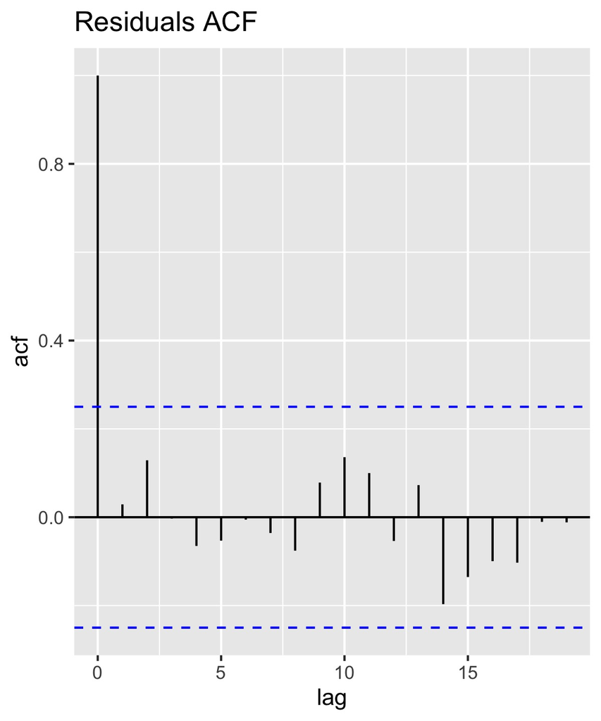

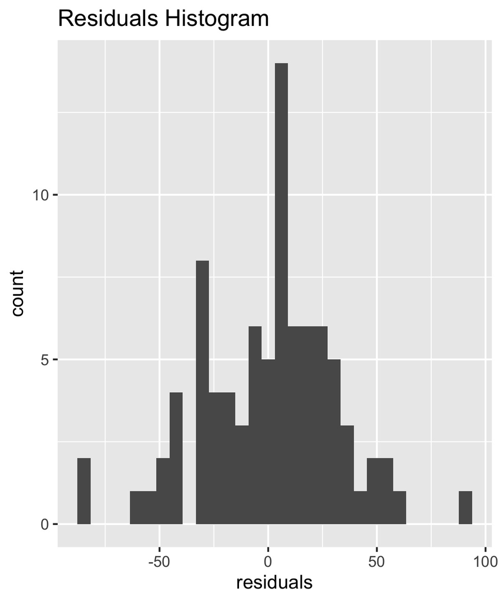

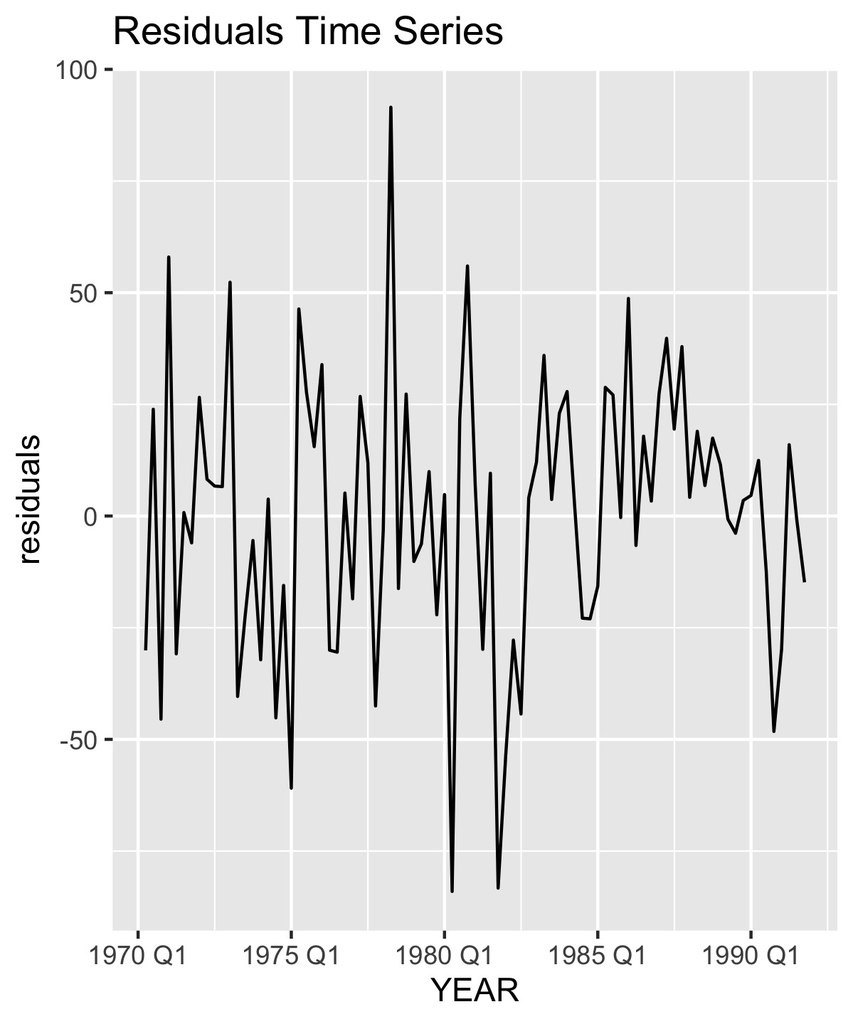

```r
knitr::include_graphics(c("finalmodel_acf.jpg", "finalmodel_histogram.jpg", "finalmodel_residuals.jpg"))
```

Residuals look like white noise.

## Let’s compare Predictions of both GDP Models

Look 1 quarter ahead GDP forecast for Q1 1992 using these models.

```r
model1_predh1 = exp(fc$.mean[1])

model2_predh1 = gdpdata$GDP[88] +  predict(modDGDP, 1 )$pred[1]

actual_gdp = 4873.7

df = data.frame(model=c("ARIMA(1,1,0", "ARIMA(12,1,0)"),
                source = c("fable algo", "manual expert") ,
                prediction = c( model1_predh1, model2_predh1) ,
                error_pct = 100 * c( ( model1_predh1 / actual_gdp) - 1, (model2_predh1 / actual_gdp) -1 ) ,
                actual = c(actual_gdp, actual_gdp)
                  )

df %>% kable(caption="Comparison of GDP Prediction", digits=2) %>%
  kable_styling(bootstrap_options = c("hover", "striped"))
```

Comparison of GDP Prediction

| model | source | prediction | error_pct | actual |
| --- | --- | --- | --- | --- |
| ARIMA(1,1,0 | fable algo | 4890.59 | 0.35 | 4873.7 |
| ARIMA(12,1,0) | manual expert | 4885.11 | 0.23 | 4873.7 |

Clearly, ARIMA(12,1,0) produces the better forecast.

# Forecast United States GDP since 2000

```r
# Read in GDP recent
gdp_rawdata <- read.table("US_GDP_Multpl.txt", sep = '\t', skip=4, header = TRUE)

# Temporary Year column
gdp_rawdata$Year <- substr(gdp_rawdata$Date, 9, 12)
# Temporary Quarter column
gdp_rawdata$Quarter <- ifelse(str_detect(gdp_rawdata$Date, "Mar"), "Q1",
                        ifelse(str_detect(gdp_rawdata$Date, "Jun"), "Q2",
                         ifelse(str_detect(gdp_rawdata$Date, "Sep"), "Q3",
                          ifelse(str_detect(gdp_rawdata$Date, "Dec"), "Q4", NA))))

# Temp Date2 column to format quarter value properly
gdp_rawdata$Date2 <- str_c(gdp_rawdata$Year, ' ', gdp_rawdata$Quarter)

gdp_data <- gdp_rawdata %>% select(Date2, Value)

# Remove the trillions from the Value column and define as numeric
gdp_data$GDP <- sub("\\ .*", "", gdp_data$Value)
gdp_data$GDP <- as.numeric(gdp_data$GDP)

# Rename Date2 to Quarter for accuracy
gdp_data$Quarter <- gdp_data$Date2

# Define tsibble object for Quarter and GDP with Quarter as index
gdp_data_ts <- gdp_data %>% select(c(Quarter, GDP)) %>%
  mutate(Quarter = yearquarter(Quarter)) %>%
  as_tsibble(index=Quarter)

# Output for tsibble format confirmation
tail(gdp_data_ts)
```

```
## # A tsibble: 6 x 2 [1Q]
##   Quarter   GDP
##     <qtr> <dbl>
## 1 2020 Q1  19.0
## 2 2020 Q2  17.3
## 3 2020 Q3  18.6
## 4 2020 Q4  18.8
## 5 2021 Q1  19.1
## 6 2021 Q2  19.4
```

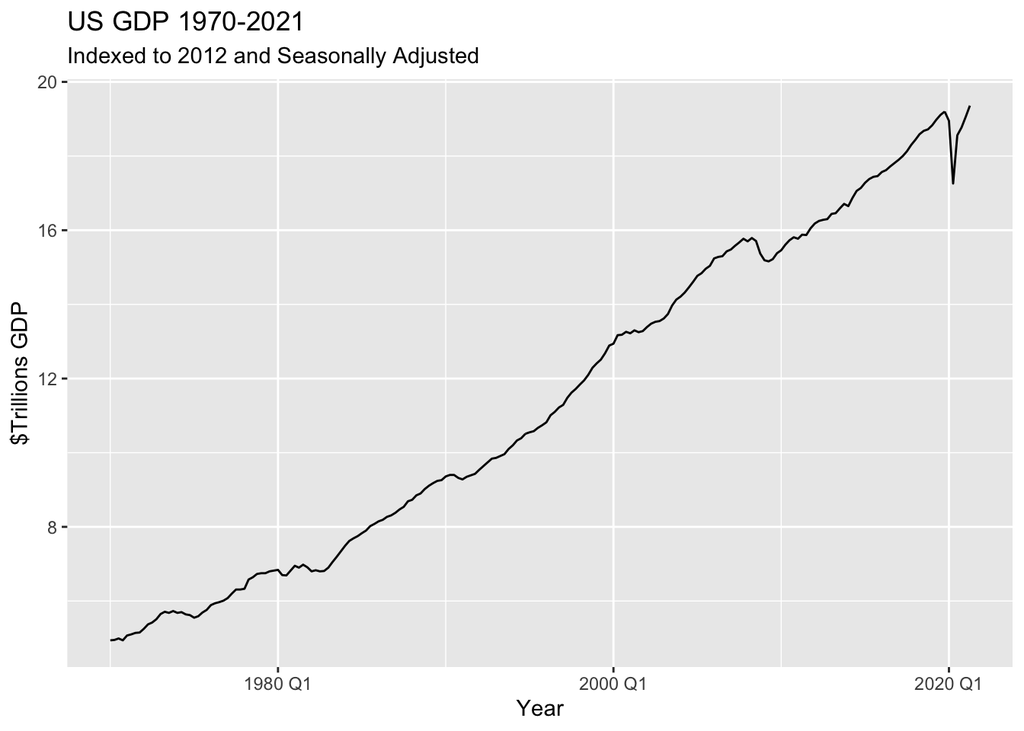

```r
# Simple visualization
gdp_data_ts %>% autoplot(GDP) +
  labs(title="US GDP 1970-2021", subtitle="Indexed to 2012 and Seasonally Adjusted") +
  xlab("Year") +
  ylab("$Trillions GDP")
```

```r
# Calculate log of GDP
gdp_data_ts %>% mutate( logGDP = log(GDP)) -> gdpdata

gdpdata
```

```
## # A tsibble: 206 x 3 [1Q]
##    Quarter   GDP logGDP
##      <qtr> <dbl>  <dbl>
##  1 1970 Q1  4.94   1.60
##  2 1970 Q2  4.95   1.60
##  3 1970 Q3  4.99   1.61
##  4 1970 Q4  4.94   1.60
##  5 1971 Q1  5.07   1.62
##  6 1971 Q2  5.1    1.63
##  7 1971 Q3  5.14   1.64
##  8 1971 Q4  5.15   1.64
##  9 1972 Q1  5.25   1.66
## 10 1972 Q2  5.37   1.68
## # … with 196 more rows
```

```r
# Generate ARIMA model
fit <- gdpdata %>% model(ARIMA(logGDP))
report(fit)
```

```
## Series: logGDP
## Model: ARIMA(0,1,0) w/ drift
##
## Coefficients:
##       constant
##         0.0067
## s.e.    0.0008
##
## sigma^2 estimated as 0.0001333:  log likelihood=624.22
## AIC=-1244.44   AICc=-1244.38   BIC=-1237.79
```

```r
# Set training data from 1970 to 2000
train_2000 <- gdpdata %>%
  filter_index("1970 Q1" ~ "2000 Q4")

# Set training data from 1970 to 2010
train_2010 <- gdpdata %>%
  filter_index("1970 Q1" ~ "2010 Q4")

# Set training data from 1970 to 2020
train_2020 <- gdpdata %>%
  filter_index("1970 Q1" ~ "2020 Q4")

# Fit the models
gdp_fit_2000 <- train_2000 %>% model(ARIMA(GDP))
gdp_fit_2010 <- train_2010 %>% model(ARIMA(GDP))
gdp_fit_2020 <- train_2020 %>% model(ARIMA(GDP))

# Generate forecasts for 21 years
gdp_fc_2000 <- gdp_fit_2000 %>% forecast(h = 84)
# Generate forecasts for 11 years
gdp_fc_2010 <- gdp_fit_2010 %>% forecast(h = 44)
# Generate forecasts for 1 year
gdp_fc_2020 <- gdp_fit_2020 %>% forecast(h = 4)

# Plot forecasts against actual values
gdp_fc_2000 %>%
  autoplot(train_2000) +
  autolayer(
    filter_index(gdpdata, "2001 Q1" ~ .),
    colour = "black"
  ) +
  labs(
    y = "Trillions",
    title = "Forecasts for US GDP"
  ) +
  guides(colour = guide_legend(title = "Forecast"))

tail(gdp_fc_2000)

# Plot forecasts against actual values
gdp_fc_2010 %>%
  autoplot(train_2010) +
  autolayer(
    filter_index(gdpdata, "2011 Q1" ~ .),
    colour = "black"
  ) +
  labs(
    y = "Trillions",
    title = "Forecasts for US GDP"
  ) +
  guides(colour = guide_legend(title = "Forecast"))

tail(gdp_fc_2010)

# Plot forecasts against actual values
gdp_fc_2020 %>%
  autoplot(train_2020) +
  autolayer(
    filter_index(gdpdata, "2021 Q1" ~ .),
    colour = "black"
  ) +
  labs(
    y = "Trillions",
    title = "Forecasts for US GDP"
  ) +
  guides(colour = guide_legend(title = "Forecast"))

tail(gdp_fc_2020)
```

[output not shown]

Filter on data for just the 21st century

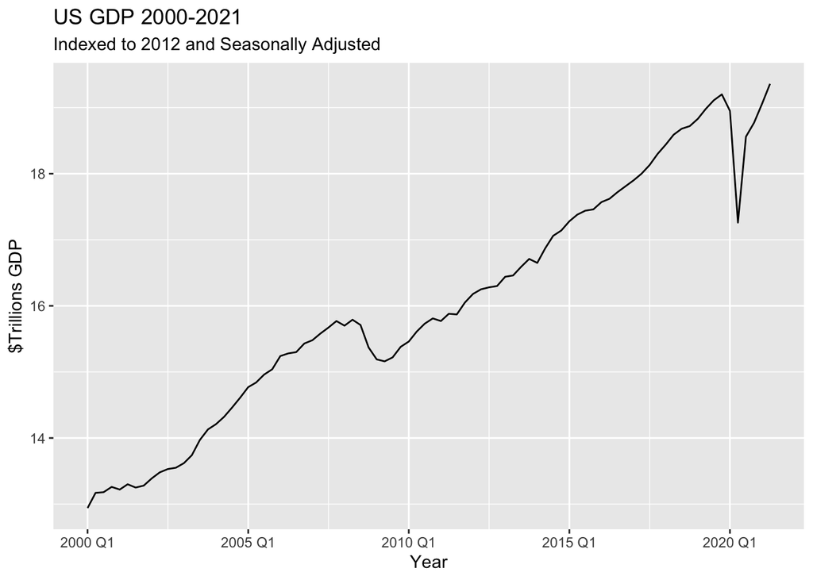

```r
# tsibble name to start: gdp_data_ts
gdp_since_2000 <- gdp_data_ts %>%
  filter(year(Quarter) > 1999)

# General plot of data since 2000 inclusive
gdp_since_2000 %>% autoplot(GDP) +
  labs(title="US GDP 2000-2021", subtitle="Indexed to 2012 and Seasonally Adjusted") +
  xlab("Year") +
  ylab("$Trillions GDP")
```

Construct training set based on 2000 through 2018

Difference plot appears stationarity besides the 2008 dip

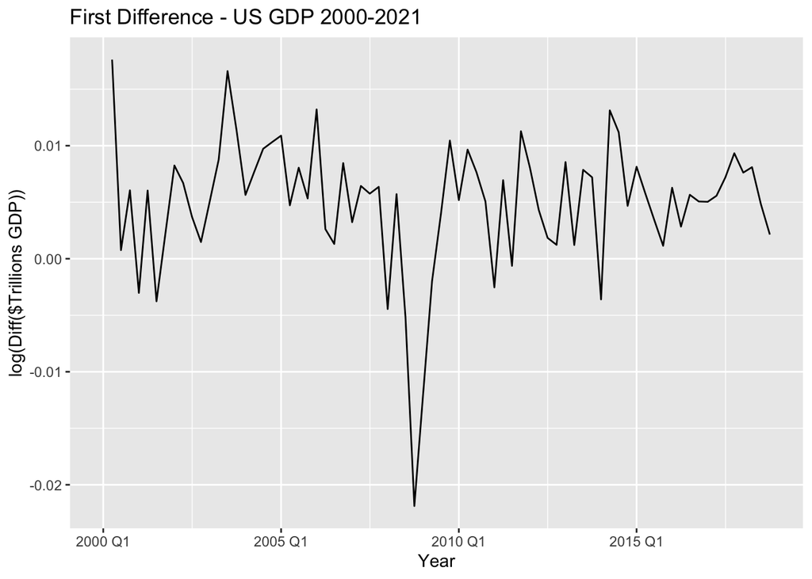

```r
# Define training data of 2000-2018
gdp_train <- gdp_since_2000 %>%
  filter(year(Quarter) < 2019)

# Plot first difference
# Result diff with 2008 implies not exactly white noise
gdp_since_2000 %>%
  filter(year(Quarter) < 2019) %>% autoplot(difference(log(GDP), lag=1)) +
  labs(title=  "First Difference - US GDP 2000-2021") +
  xlab("Year") + ylab("log(Diff($Trillions GDP))")
```

Visualize the ACF and PACF plots based on the GDP after 1 difference

- ACF shows lag at 1 and lag 2 are correlated to the current year
- PACF shows lag at 1 is correlated to the current year
- Again, despite the 2008 dip, the data does appear to have stationarity

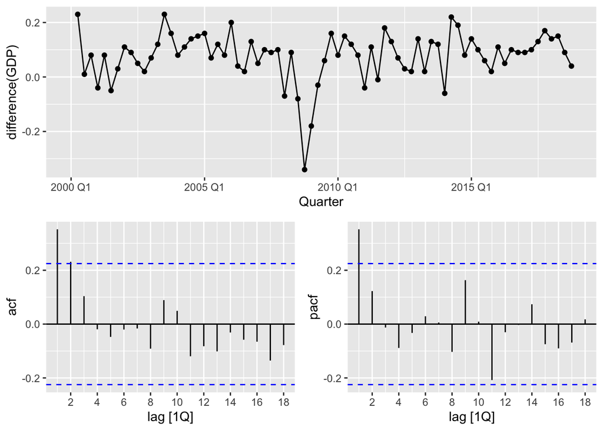

```r
# Check ACF and PACF plots
gdp_since_2000 %>%
  filter(year(Quarter) < 2019) %>%
  gg_tsdisplay( difference(GDP), plot_type='partial')
```

Fit the `fable` ARIMA model to the training set

Output the residuals from the model

- Residuals appear similar to white noise
- No correlation based on ACF plot
- Histogram shows near normal distribution with the outliers causing left skew

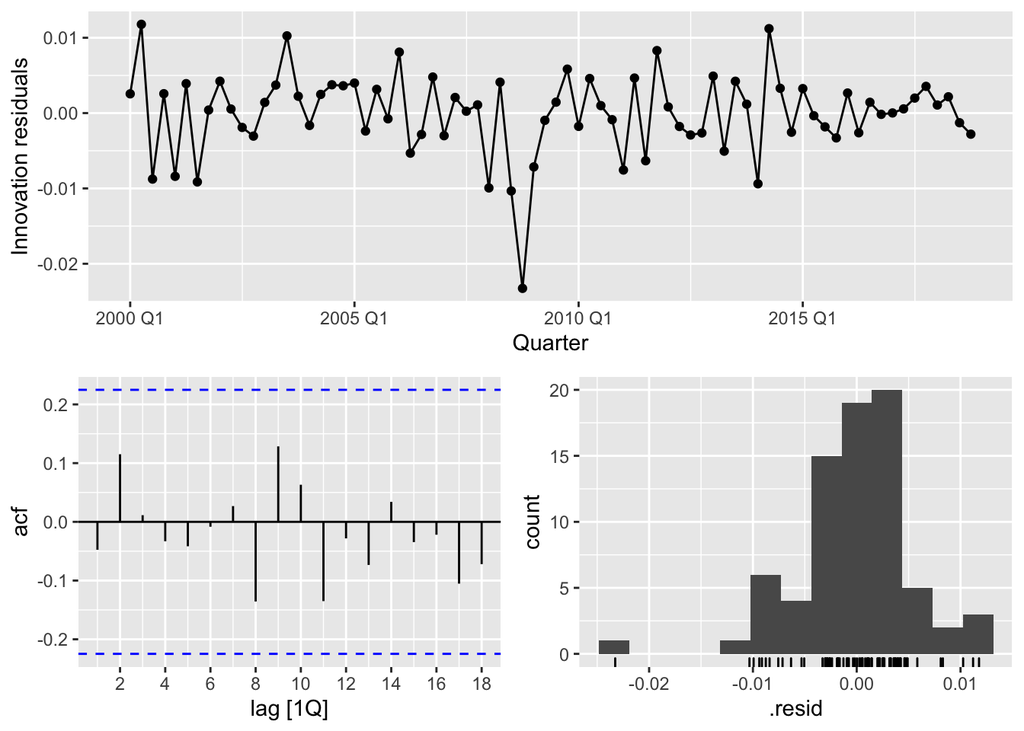

```r
# Fit ARIMA model
gdp_fit <- gdp_train %>% model(ARIMA(log(GDP)))

# Check residuals
gdp_fit %>% gg_tsresiduals()
```

Output the model definition

Results show ARIMA(1,1,0) with drift

AIC=-563.31 (the lower the better, even negative)

```r
# Output model
report(gdp_fit)
```

```
## Series: GDP
## Model: ARIMA(1,1,0) w/ drift
## Transformation: log(GDP)
##
## Coefficients:
##          ar1  constant
##       0.3583    0.0032
## s.e.  0.1109    0.0006
##
## sigma^2 estimated as 3.042e-05:  log likelihood=284.66
## AIC=-563.31   AICc=-562.97   BIC=-556.36
```

Check Ljung-Box test on residuals

- p-value is too high to reject the null hypothesis, thus we cannot assume the values are dependent on each other.

```r
# Model residuals with Ljung-Box
augment(gdp_fit) %>% features(.innov, ljung_box, lag=12, dof=2)
```

```
## # A tibble: 1 × 3
##   .model          lb_stat lb_pvalue
##   <chr>             <dbl>     <dbl>
## 1 ARIMA(log(GDP))    6.71     0.752
```

### Forecast the data after 2018

Forecast appears to follow an upward trend similar to the plot from 2000-2018

```r
# Forecast
gdp_fc <- gdp_fit %>%
  forecast(new_data = anti_join(gdp_since_2000, gdp_train))
```

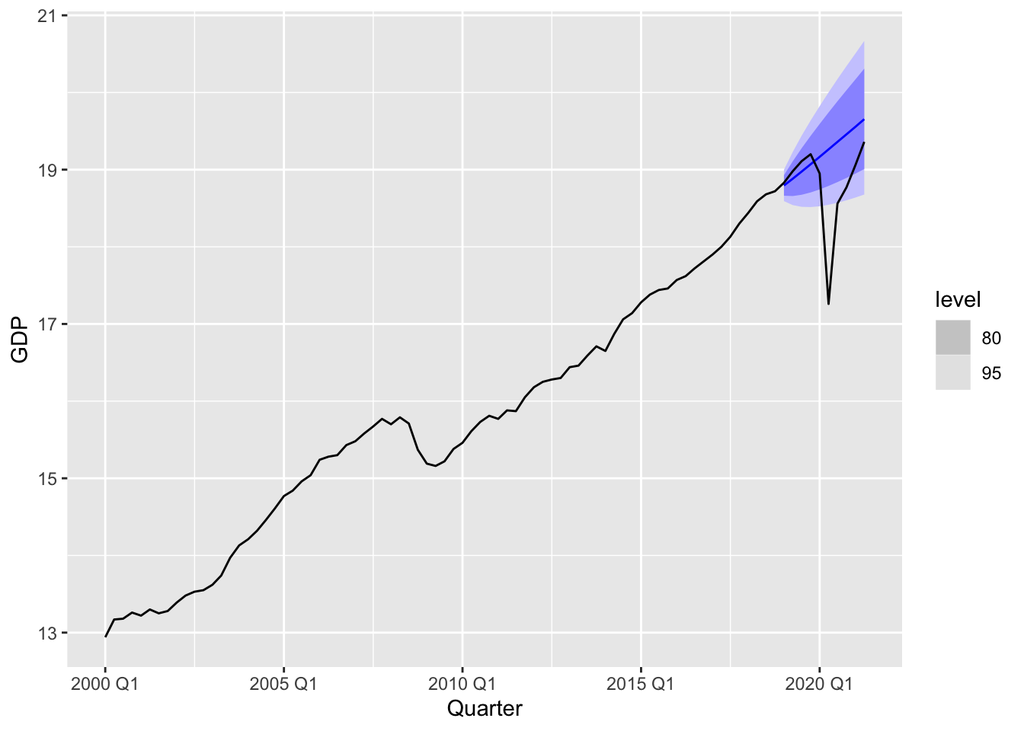

```r
gdp_fc %>% autoplot(gdp_since_2000)
```

```r
gdp_fit %>% accuracy()
```

```
## # A tibble: 1 × 10
##   .model          .type       ME   RMSE    MAE      MPE  MAPE  MASE RMSSE    ACF1
##   <chr>           <chr>    <dbl>  <dbl>  <dbl>    <dbl> <dbl> <dbl> <dbl>   <dbl>
## 1 ARIMA(log(GDP)) Trai… -8.86e-4 0.0827 0.0609 -0.00516 0.397 0.169 0.213 -0.0440
```

```r
gdp_fc %>% accuracy(gdp_since_2000)
```

```
## # A tibble: 1 × 10
##   .model          .type     ME  RMSE   MAE   MPE  MAPE  MASE RMSSE  ACF1
##   <chr>           <chr>  <dbl> <dbl> <dbl> <dbl> <dbl> <dbl> <dbl> <dbl>
## 1 ARIMA(log(GDP)) Test  -0.410 0.745 0.489 -2.28  2.69  1.36  1.91 0.345
```

Training set results: RMSE of 0.0827

Forecast results: RMSE of 0.745

## Model 2: Manual approach

Use `arima()` from the stats library.

```r
## Method 2
gdp_since_2000$DGDP = difference(gdp_since_2000$GDP,lag=1)

gdp_fit_2 <- arima(gdp_since_2000$DGDP[2:76], order = c(1, 0, 2), include.mean=TRUE)
# Output result
gdp_fit_2
```

```
##
## Call:
## arima(x = gdp_since_2000$DGDP[2:76], order = c(1, 0, 2), include.mean = TRUE)
##
## Coefficients:
##          ar1      ma1     ma2  intercept
##       0.4050  -0.0934  0.1212     0.0780
## s.e.  0.3295   0.3274  0.1669     0.0162
##
## sigma^2 estimated as 0.006759:  log likelihood = 80.87,  aic = -151.74
```

Model results in AIC=-151.74 which is more than the fable ARIMA model.

```r
kpss_val <- tseries::kpss.test(gdp_since_2000$DGDP[2:76], null=c("Level"), lshort = FALSE)
kpss_val
```

```
##
##  KPSS Test for Level Stationarity
##
## data:  gdp_since_2000$DGDP[2:76]
## KPSS Level = 0.10794, Truncation lag parameter = 11, p-value = 0.1
```

```r
adf_val <- tseries::adf.test(gdp_since_2000$DGDP[2:76], k = 3 )
adf_val
```

```
##
##  Augmented Dickey-Fuller Test
##
## data:  gdp_since_2000$DGDP[2:76]
## Dickey-Fuller = -3.6548, Lag order = 3, p-value = 0.03461
## alternative hypothesis: stationary
```

```r
ljung_box(gdp_fit_2$residuals, lag=12, dof=4)
```

```
##   lb_stat lb_pvalue
## 7.8233017 0.4509183
```

```r
head(gdp_since_2000)
```

```
## # A tsibble: 6 x 3 [1Q]
##   Quarter   GDP    DGDP
##     <qtr> <dbl>   <dbl>
## 1 2000 Q1  12.9 NA
## 2 2000 Q2  13.2  0.230
## 3 2000 Q3  13.2  0.0100
## 4 2000 Q4  13.3  0.0800
## 5 2001 Q1  13.2 -0.0400
## 6 2001 Q2  13.3  0.0800
```

```r
# Visualize the manual model residuals
# NEED TO UPDATE
diag_modgdp = data.frame( YEAR =  gdp_since_2000$Quarter[2:76], residuals = gdp_fit_2$residuals, DGDP = gdp_since_2000$DGDP[2:76] )


acf_data = acf(diag_modgdp$residuals, plot=FALSE)

df_acfdata = with(acf_data, data.frame(lag, acf))



q <- ggplot(data=df_acfdata, aes(x=lag,y=acf)) + geom_hline(aes(yintercept=0)) + geom_segment(aes(xend=lag,yend=0)) +
   geom_hline(yintercept=.25, col="blue", linetype=2) +
   geom_hline(yintercept=-.25, col="blue", linetype=2) + ggtitle("Residuals ACF")

r <- ggplot(data=diag_modgdp) + geom_histogram(aes(x=residuals)) + ggtitle("Residuals Histogram")

s <- ggplot(data=diag_modgdp) + geom_line(aes(x=YEAR,y=residuals)) + ggtitle("Residuals Time Series")

#plot(diag_modgdp$YEAR, diag_modgdp$residuals)
#hist(diag_modgdp$residuals, main="Residuals")

ggsave("finalmodel_acf_2.jpg", q)
ggsave("finalmodel_histogram_2.jpg", r)
ggsave("finalmodel_residuals_2.jpg", s)
```

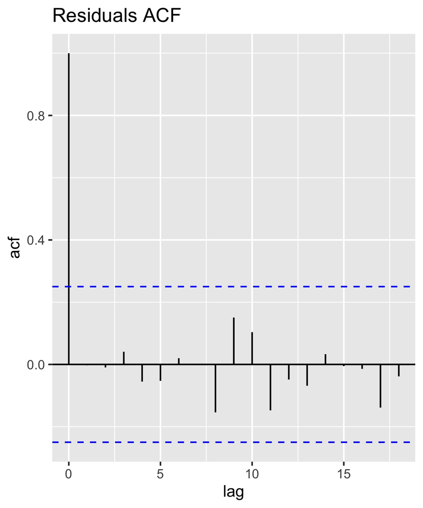

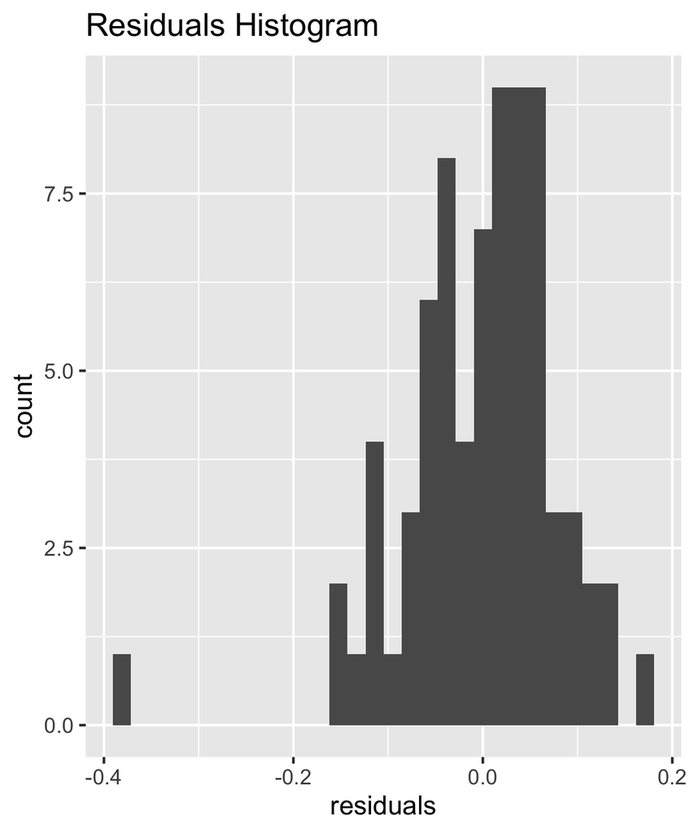

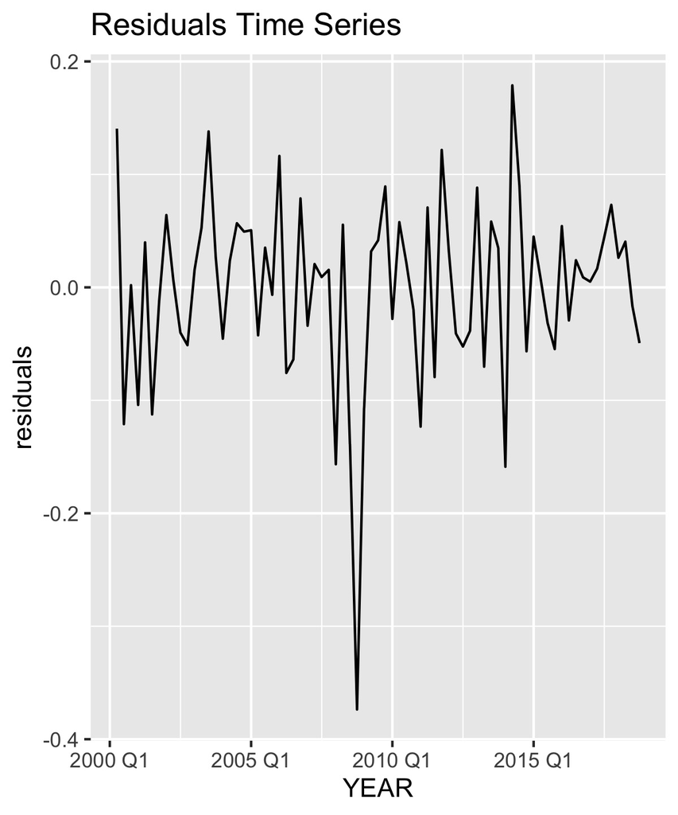

```r
# Plot the visuals
# NEED TO UPDATE
knitr::include_graphics(c("finalmodel_acf_2.jpg", "finalmodel_histogram_2.jpg", "finalmodel_residuals_2.jpg"))
```

```r
model1_pred=c()
model2_pred=c()
gdp_actual=c()

for (i in 1:4) {
  model1_pred[i] = (gdp_fc$.mean[i])

  if (i == 1) {
    model2_pred[i] = gdp_since_2000$GDP[76] +  predict(gdp_fit_2, i )$pred[i]
  } else {
    model2_pred[i] = model2_pred[i-1] +  predict(gdp_fit_2, i )$pred[i]
  }

  gdp_actual[i] = gdp_since_2000$GDP[76+i]
}

values_2019 <- data.frame(ARIMA_Fable=model1_pred, ARIMA_Manual=model2_pred, GDP_Values=gdp_actual)

values_2019$Fable_Err_Pct  <- 100 * (1 - values_2019$ARIMA_Fable  / values_2019$GDP_Values)
values_2019$Manual_Err_Pct <- 100 * (1 - values_2019$ARIMA_Manual / values_2019$GDP_Values)

values_2019
```

```
##   ARIMA_Fable ARIMA_Manual GDP_Values Fable_Err_Pct Manual_Err_Pct
## 1    18.79480     18.78520      18.83     0.1869485      0.2379181
## 2    18.88254     18.85203      18.98     0.5134981      0.6742337
## 3    18.97526     18.92550      19.11     0.7050744      0.9654685
## 4    19.07009     19.00166      19.20     0.6766310      1.0330409
```